# Prediction Assignment

Mohammad Ali farajian

April 7, 2019

Apply your machine learning algorithm to the 20 test cases available in the test data above and submit your predictions in appropriate format to the Course Project Prediction Quiz for automated grading.

Data:

The training data for this project are available here:

https://d396qusza40orc.cloudfront.net/predmachlearn/pml-training.csv

The test data are available here:

https://d396qusza40orc.cloudfront.net/predmachlearn/pml-testing.csv

The data for this project come from this source: http://groupware.les.inf.puc-rio.br/har.

## Code and Results

Packages, Libraries, Seed

Installing packages, loading libraries, and setting the seed for reproduceability:

install.packages(“caret”),install.packages(“randomForest”),install.packages(“rpart”),install.packages(“rpart.plot”)

```r
library(caret)
library(randomForest) #Random forest for classification and regression
```

```r
library(rpart) # Regressive Partitioning and Regression trees
library(rpart.plot) # Decision Tree plot
# setting the overall seed for reproduceability
set.seed(1000)
```

## Loading data sets and preliminary cleaning

First we want to load the data sets into R and make sure that missing values are coded correctly. Irrelevant variables will be deleted. Results will be hidden from the report for clarity and space considerations.

```r
# After saving both data sets into my working directory
# Some missing values are coded as string  "NA" or"#DIV/0!" or""  - these will be changed to NA.

# Loading the training data set into my R session replacing all missing with "NA"

trainingset <- read.csv("pml-training.csv", na.strings=c("NA","#DIV/0!", ""))

# Loading the testing data set
testingset <- read.csv("pml-testing.csv", na.strings=c("NA","#DIV/0!", ""))
```

```r
# Check dimensions for number of variables and number of observations
dim(trainingset)
```

```
## [1] 19622   160
```

```r
dim(testingset)
```

```
## [1]  20 160
```

```r
# Delete columns with all missing values
trainingset<-trainingset[,colSums(is.na(trainingset)) == 0]
testingset <-testingset[,colSums(is.na(testingset)) == 0]
```

```r
# Some variables are irrelevant to our current project: user_name, raw_timestamp_part_1, raw_timestamp_part_,2 cvtd_timestamp, new_window, and  num_window (columns 1 to 7). We can delete these variables.
trainingset   <-trainingset[,-c(1:7)]
testingset <-testingset[,-c(1:7)]
```

```r
# and have a look at our new datasets:
dim(trainingset)
```

```
## [1] 19622    53
```

```r
dim(testingset)
```

```
## [1] 20 53
```

# Partitioning the training data set to allow cross-validation

In order to perform cross-validation, the training data set is partionned into 2 sets: subTraining (70%) and subTest (30%). This will be performed using random subsampling without replacement.

```r
midtrainset <- createDataPartition(y=trainingset$classe, p=0.70, list=FALSE)
SubTrainingSet <- trainingset[midtrainset, ]
SubTestingSet <- trainingset[-midtrainset, ]
```

## A look at the Data

The variable “classe” contains 5 levels: A, B, C, D and E. A plot of the outcome variable will allow us to see the frequency of each levels in the SubTrainingSet data set and compare one another.

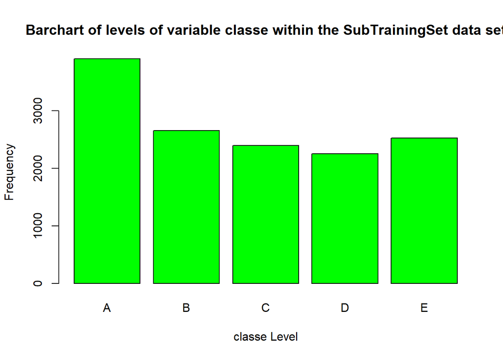

```r
plot(SubTrainingSet$classe, col="green", main="Barchart of levels of variable classe within the SubTrainingSet data set", xlab="classe Level", ylab="Frequency")
```

```r
model1 <- rpart(classe ~ ., data=SubTrainingSet, method="class")

prediction1 <- predict(model1, SubTestingSet, type = "class")
```

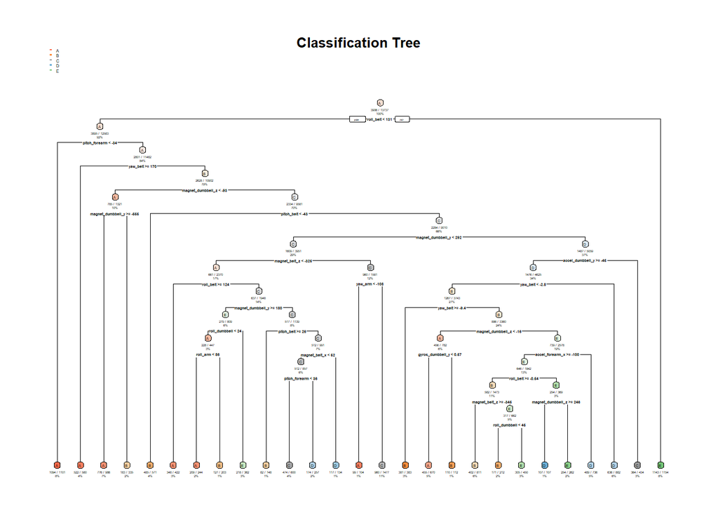

```r
# Plot the Decision Tree
rpart.plot(model1, main="Classification Tree", extra=102, under=TRUE, faclen=0)
```

```r
# Test results on our SubTestingSet data set:
confusionMatrix(prediction1, SubTestingSet$classe)
```

```
## Confusion Matrix and Statistics
##
##           Reference
## Prediction    A    B    C    D    E
##          A 1461  150   10   57   50
##          B   88  814  138   68   71
##          C   14  111  790  161   83
##          D   44   56   47  643   82
##          E   67    8   41   35  796
##
## Overall Statistics
##
##                Accuracy : 0.7653
##                  95% CI : (0.7543, 0.7761)
##     No Information Rate : 0.2845
##     P-Value [Acc > NIR] : < 2.2e-16
##
##                   Kappa : 0.7028
##
##  Mcnemar's Test P-Value : < 2.2e-16
##
## Statistics by Class:
##
##                      Class: A Class: B Class: C Class: D Class: E
## Sensitivity            0.8728   0.7147   0.7700   0.6670   0.7357
## Specificity            0.9366   0.9231   0.9241   0.9535   0.9686
## Pos Pred Value         0.8455   0.6904   0.6816   0.7374   0.8405
## Neg Pred Value         0.9488   0.9309   0.9501   0.9360   0.9421
## Prevalence             0.2845   0.1935   0.1743   0.1638   0.1839
## Detection Rate         0.2483   0.1383   0.1342   0.1093   0.1353
## Detection Prevalence   0.2936   0.2003   0.1969   0.1482   0.1609
## Balanced Accuracy      0.9047   0.8189   0.8470   0.8102   0.8521
```

## Second prediction model: Using Random Forest

```r
model2 <- randomForest(classe ~. , data=SubTrainingSet, method="class")

# Predicting:
prediction2 <- predict(model2, SubTestingSet, type = "class")
```

```r
# Test results on SubTestingSet data set:
confusionMatrix(prediction2, SubTestingSet$classe)
```

```
## Confusion Matrix and Statistics
##
##           Reference
## Prediction    A    B    C    D    E
##          A 1671    6    0    0    0
##          B    3 1132    6    0    0
##          C    0    1 1018   11    0
##          D    0    0    2  952    3
##          E    0    0    0    1 1079
##
## Overall Statistics
##
##                Accuracy : 0.9944
##                  95% CI : (0.9921, 0.9961)
##     No Information Rate : 0.2845
##     P-Value [Acc > NIR] : < 2.2e-16
##
##                   Kappa : 0.9929
##
##  Mcnemar's Test P-Value : NA
##
## Statistics by Class:
##
##                      Class: A Class: B Class: C Class: D Class: E
## Sensitivity            0.9982   0.9939   0.9922   0.9876   0.9972
## Specificity            0.9986   0.9981   0.9975   0.9990   0.9998
## Pos Pred Value         0.9964   0.9921   0.9883   0.9948   0.9991
## Neg Pred Value         0.9993   0.9985   0.9984   0.9976   0.9994
## Prevalence             0.2845   0.1935   0.1743   0.1638   0.1839
## Detection Rate         0.2839   0.1924   0.1730   0.1618   0.1833
## Detection Prevalence   0.2850   0.1939   0.1750   0.1626   0.1835
## Balanced Accuracy      0.9984   0.9960   0.9949   0.9933   0.9985
```

## Decision on which Prediction Model is better:

Random Forest algorithm performed better than Decision Trees. Accuracy for Random Forest model was 0.9944 (95% CI : (0.9921, 0.9961)) compared to Decision Tree model with Accuracy : 0.7653  
(95% CI : (0.7543, 0.7761)) . The Random Forests model is choosen. The expected out-of-sample error is estimated at 0.0056, or 0.56%.

## final pridict Submission

Here is the final outcome based on the Prediction Model Random Forest applied against the Testing dataset

```r
# predict outcome levels on the original Testing data set using Random Forest algorithm
predictfinal <- predict(model2, testingset, type="class")
predictfinal
```

```
##  1  2  3  4  5  6  7  8  9 10 11 12 13 14 15 16 17 18 19 20
##  B  A  B  A  A  E  D  B  A  A  B  C  B  A  E  E  A  B  B  B
## Levels: A B C D E
```